# Income and Attrition

Dan Simonet

10/31/2021

The current report analyzes income disparities and attrition for the IBM workforce. the sample contains 1470 employees spread across 3 departments.

### ANOVA Analysis

A 2 x 3 between-group ANOVA was conducted to evaluate income differences by department and gender. Results suggest no significant effect for gender, $F_{1, 1437} = .9038, p = .34$, or the interaction, $F_{2,1437} = .42, p = .66$, but a marginal effect for department, $F_{2, 1437} = 2.59, p = .08$, with sales (*M* = $6,953) trending towards higher monthly pay than HR (*M* = $6,655) and research (*M* = $6,289).

| Effect | df | MSE | F | ges | p.value |
| --- | --- | --- | --- | --- | --- |
| Department | 2, 1437 | 22280269.72 | 2.59 + | .004 | .075 |
| Gender | 1, 1437 | 22280269.72 | 0.90 | <.001 | .342 |
| Department:Gender | 2, 1437 | 22280269.72 | 0.42 | <.001 | .656 |

### Post-Hocs

Eyeballing narrower sub-group differences suggests male researchers make less than male salesmen ($\Delta M=\$839.36$) and female HR reps ($\Delta M=\$1,147.91$). However, Tukey’s HSD test for multiple comparisons on estimated marginal means across all sub-group pairings provides further evidence of no significant pay differences.

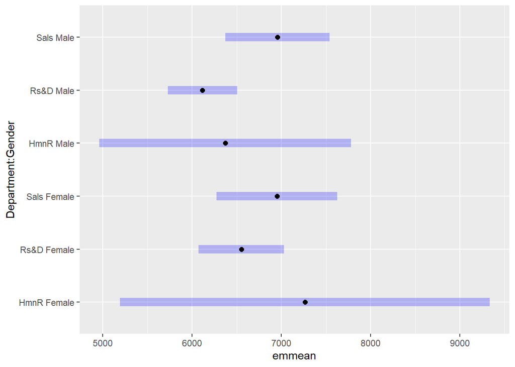

#### Attrition

A logistic regression shows improvements in monthly income, work life balance, and job satisfaction all uniquely contribute to reductions in attrition. Odds ratios suggest a point increase in balance or satisfaction leads to a 22% reduction in the odds of turnover whereas making $1000 extra per month leads to a 12% drop.

|  | Attrition |  |  |
| --- | --- | --- | --- |
| Predictors | Odds Ratios | CI | p |
| (Intercept) | 1.51 | 0.76 – 2.98 | 0.237 |
| MonthlyIncome/1000 | 0.88 | 0.84 – 0.92 | **<0.001** |
| WorkLifeBalance | 0.78 | 0.64 – 0.95 | **0.014** |
| JobSatisfaction | 0.78 | 0.69 – 0.89 | **<0.001** |
| Observations | 1443 |  |  |
| R<sup>2</sup> Tjur | 0.046 |  |  |

The following plot illustrates how the probability of attrition changes across varying predictor levels. As can be seen, those making over $15,000 are likely to stay regardless of job satisfaction and balance. However, for those making $5,000 or less a month the differences in attitudinal extremes translates into a nearly 20% reduction in probability of departure.

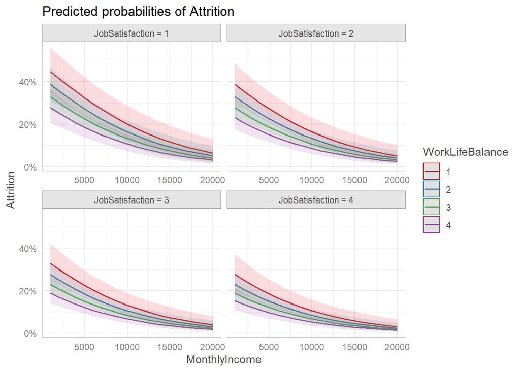